# Zależność między ceną mieszkań a ich cechami na rynku nieruchomości w Warszawie

Zuzanna Winiarska

Rynek nieruchomości w Warszawie, pulsujący życiem i odzwierciedlający dynamiczny rozwój miasta, stanowi niezwykle interesujący obszar badawczy. W kontekście tego nieustannego ruchu oraz różnorodnych czynników wpływających na kształtowanie cen mieszkań, przedstawiam projekt, którego celem jest głęboka analiza zależności między cenami nieruchomości a ich różnorodnymi cechami. Poprzez analizę szerokiego zakresu danych, obejmujących istotne atrybuty nieruchomości, dążę do zidentyfikowania kluczowych czynników wpływających na kształtowanie cen, co może być cenną wskazówką dla inwestorów, deweloperów oraz przyszłych nabywców.

#### **Kontekst rynku nieruchomości w Warszawie**

Warszawa, będąca sercem Polski, to nie tylko stolica kraju, ale także centrum gospodarcze i kulturalne. Szybki rozwój miasta, innowacyjne projekty urbanistyczne oraz rosnące zapotrzebowanie na mieszkania sprawiają, że rynek nieruchomości w Warszawie jest miejscem o wyjątkowej dynamice i złożoności. Zmieniające się trendy, rozwój infrastruktury, a także czynniki społeczno-ekonomiczne, wpływają na ceny mieszkań, tworząc fascynujące pole badań.

[figure not shown]

### **Ramka danych**

#### **Pochodzenie danych**

Ramka danych użyta w projekcie pochodzi głównie z platformy ogłoszeniowej Otodom.pl, będącej jednym z głównych źródeł informacji o rynku nieruchomości w Warszawie. Zawiera informacje na temat blisko 7 000 ofert mieszkaniowych z terenu całej Warszawy. Dodatkowo, zbiór danych został wzbogacony przeze mnie o informacje geograficzne uzyskane z Google Maps, zawierające współrzędne geograficzne osiedli. Informacja o położeniu dzielnic względem Wisły została ręcznie dodana, dostarczając dodatkowego kontekstu przestrzennego.

#### **Struktura ramki danych**

Ramka danych jest tabelaryczną strukturą, gdzie każdy wiersz reprezentuje pojedyncze ogłoszenie dotyczące nieruchomości. Poszczególne kolumny zawierają różne informacje na temat każdej nieruchomości. Oto główne kategorie zmiennych:

1. **Podstawowe informacje o nieruchomości:**
   - **Nazwa ogłoszenia:** Unikalna nazwa identyfikująca ogłoszenie.
   - **Cena:** Cena nieruchomości wyrażona w zł.
   - **Cena za metr kwadratowy** Cena za jeden metr kwadratowy wyrażona w zł.
   - **Liczba pokoi:** Liczba pokoi w nieruchomości.
   - **Powierzchnia:** Powierzchnia nieruchomości w metrach kwadratowych.
   - **Piętro:** Piętro, na którym znajduje się nieruchomość.
   - **Balkon-taras-ogródek:** Informacja o obecności balkonu, tarasu lub ogródka.
2. **Lokalizacja:**
   - **Osiedle:** Nazwa osiedla, na którym znajduje się nieruchomość.
   - **Dzielnica:** Dzielnica Warszawy, w której zlokalizowana jest nieruchomość.
   - **Położenie względem Wisły:** Informacja o tym, czy nieruchomość znajduje się na lewym czy prawym brzegu Wisły.
3. **Dodatkowe Informacje:**
   - **Forma własności:** Forma prawna własności nieruchomości.
   - **Stan:** Stan techniczny nieruchomości.
   - **Czynsz:** Opłata miesięczna za utrzymanie nieruchomości.
   - **Miejsce parkinkowe:** Informacja o dostępności miejsca parkingowego.
   - **Ogrzewanie:** System ogrzewania nieruchomości.
   - **Rynek:** Informacja o tym, czy nieruchomość znajduje się na rynku pierwotnym czy wtórnym.
   - **Typ ogłoszeniodawcy:** Kategoria ogłoszeniodawcy (np. biuro nieruchomości, prywatny).
   - **Rok budowy:** Rok, w którym nieruchomość została wybudowana (oddana do użytku).
   - **Rodzaj zabudowy:** Informacja o rodzaju zabudowy nieruchomości (np. blok, apartamentowiec).
   - **Winda:** Informacja o obecności windy.

#### **Typ danych**

Ramka danych zawiera różnorodne typy danych, w tym:

- **Dane numeryczne:** Cena, Cena za metr, Liczba pokoi, Powierzchnia, Piętro, Czynsz, Rok budowy.
- **Dane kategoryczne:** Nazwa ogłoszenia, Osiedle, Dzielnica, Forma własności, Stan, Balkon-taras-ogródek, Miejsce parkinkowe, Ogrzewanie, Rynek, Typ ogłoszeniodawcy, Rodzaj zabudowy, Winda, Położenie względem Wisły.

Warto zaznaczyć, że różnorodność typów danych pozwoli na bardziej kompleksową analizę i modelowanie, uwzględniając różne aspekty nieruchomości na warszawskim rynku.

## **Etapy pracy**

### **1. Pozyskanie danych**

Pierwszym etapem pracy było pozyskiwanie informacji ze strony głównej, gdzie skoncentrowałam się na kluczowych danych ogólnych, takich jak lokalizacja, liczba pokoi, powierzchnia, cena itp. Dane te stanowiły pierwszy etap projektu, dostarczając podstawowego zestawu informacji o ofertach nieruchomości dostępnych na rynku warszawskim.

Kolejnym etapem pozyskiwania danych było przeszukiwanie stron ofert nieruchomości wewnętrznych, bezpośrednio z linków do tych ofert. Dane dodatkowe, takie jak informacje o balkonach, miejscach parkingowych czy ogrzewaniu, były pobierane i zapisywane w wektorze. Jednak, w trakcie tego procesu, napotkałam na wyzwanie związane z brakiem jednolitej struktury informacji na poszczególnych stronach ofertowych.

W celu efektywnego zarządzania tymi nieregularnościami, zdecydowałam się na przypisanie wartości NA dla wszystkich informacji dodatkowych na samym początku procesu pobierania danych. Podejście to wymagało dodatkowych kroków w procesie analizy danych, jednak zapewniło spójność w strukturze ramki danych, co było kluczowe dla późniejszych etapów projektu.

Ponadto, skorzystałam z Google Maps, aby uzyskać współrzędne geograficzne osiedli, co pozwoliło mi na dodanie nowego wymiaru przestrzennego do moich danych. Ręczne dodanie informacji o położeniu dzielnic względem Wisły było kolejnym krokiem w uzupełnianiu ramki danych.

### **2. Przygotowanie danych (czyszczenie)**

W związku z różnorodnościami w strukturze pobranych danych, proces przygotowania danych stał się istotnym etapem. Wielokrotne wartości NA w ramce danych wynikały z faktu, że nie wszystkie informacje były dostępne na każdej stronie ofertowej. Dlatego też, dla każdej zmiennej, zastosowaliśmy warunek sprawdzający dostępność informacji przed jej przyporządkowaniem do danej kolumny. Ostatecznie, ta elastyczność w przyporządkowywaniu danych pozwoliła na stworzenie spójnej i pełnej ramki danych, jednocześnie respektując niestandardową strukturę danych pochodzących z różnych źródeł.

Ten proces przygotowawczy był kluczowy dla utrzymania spójności danych i umożliwił późniejsze skuteczne modelowanie i analizę danych.

#### **Fragment ramki**

| Nazwa_ogłoszenia | Cena | Cena_za_metr | Liczba_pokoi | Powierzchnia | Osiedle | Dzielnica | Forma_własności |
| --- | --- | --- | --- | --- | --- | --- | --- |
| Warszawa Mokotów 2 pokoje garaż taras sauna sklepy | 821000 | 22806 | 2 | 36.00 | Służewiec | Mokotów | pełna własność |
| Przestronne 3-pokojowe mieszkanie na Pradze Płd | 899000 | 11337 | 3 | 79.30 | Grochów | Praga-Południe | NA |
| 3-pokojowe mieszkanie przy ul. Kłobuckiej | 940000 | 16906 | 3 | 55.60 | Wyczółki | Ursynów | pełna własność |
| Mieszkanie 86,69 m2 z balkonem i miejscem post. | 731500 | 8438 | 3 | 86.69 | Czechowice | Ursus | pełna własność |
| GOTOWE Mieszkanie 4-pok. 81,75 m2. URSYNÓW | 986000 | 12061 | 4 | 81.75 | Jeziorki Południowe | Ursynów | pełna własność |

### **3. Analiza danych za pomocą wizualizacji**

W trzecim etapie analizy skoncentruję się na głębszym zrozumieniu informacji, korzystając z różnorodnych form wizualizacji. Wykorzystam narzędzia takie jak histogramy, wykresy słupkowe czy wykresy gęstości, aby ukazać różnorodność i rozkład danych.

Podczas analizy każdego z tych wykresów, nie tylko opiszę ich charakterystyki, ale także wyciągnę wnioski, starając się zidentyfikować ukryte zależności czy charakterystyczne tendencje. W ten sposób zamierzam dostarczyć pełniejszy obraz informacji zawartych w ramce danych.

Celem tego etapu jest nie tylko prezentacja danych w formie graficznej, ale także dostarczenie głębszego zrozumienia ich kontekstu. W ten sposób analiza wizualna stanie się narzędziem do odkrywania ukrytych wzorców i interpretowania danych w sposób bardziej kompleksowy.

#### **Wykres zależności ilości ofert mieszkaniowych od dzielnicy Warszawy**

Wykres zależności ilości ofert mieszkaniowych w zależności od dzielnicy Warszawy jest wizualizacją, która przedstawia liczbę dostępnych ofert w serwisie Otodom dla poszczególnych dzielnic tego miasta. Na osi X znajdują się nazwy dzielnic Warszawy, natomiast na osi Y ilość ofert mieszkaniowych w każdej z tych dzielnic. Wykres pozwala porównać, które dzielnice posiadają większą lub mniejszą dostępność ofert mieszkań, co może być przydatne przy analizie rynku nieruchomości w danym obszarze.

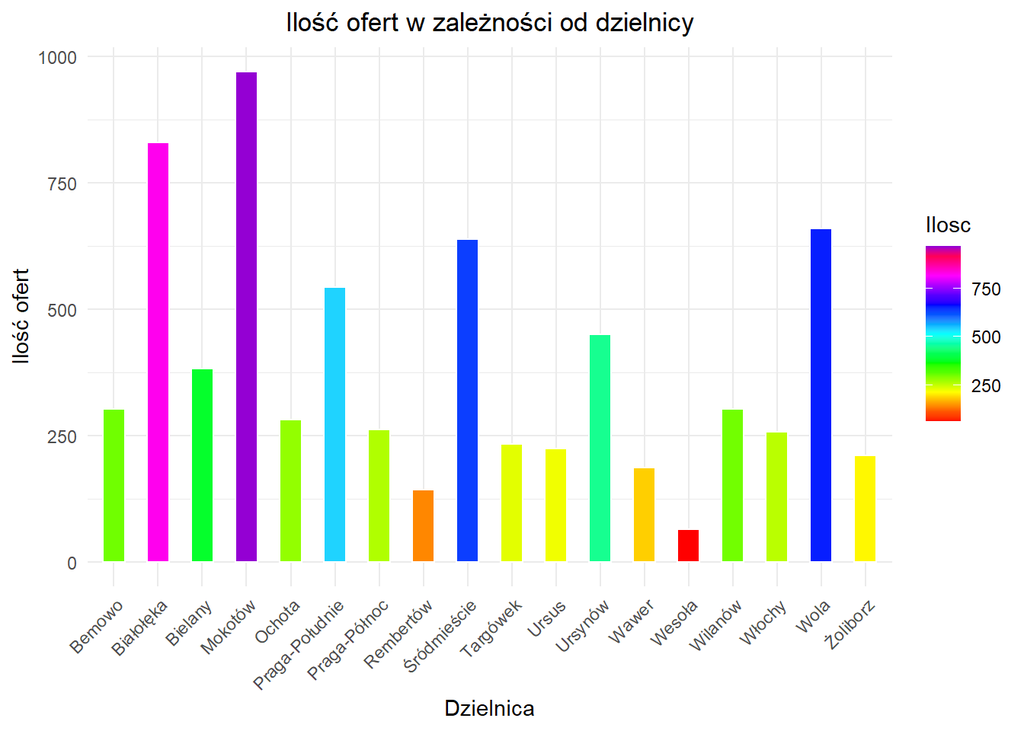

##### **Wnioski**

Podsumowując, analiza wykresu słupkowego pozwala na zobaczenie rozkładu ogłoszeń w różnych dzielnicach Warszawy, co może być kluczowe przy podejmowaniu decyzji dotyczących lokalizacji nieruchomości.

#### **Wykres zależności średniej ceny mieszkań od dzielnicy**

Wykres zależności średniej ceny mieszkań ze względu na dzielnicę Warszawy przedstawia klarowny obraz rozkładu cenowego w różnych częściach miasta. Na osi X wymienione są poszczególne dzielnice, natomiast na osi Y znajduje się średnia cena mieszkania (w tysiącach złotych) w danej lokalizacji. Gradient kolorów od zielonego do czerwonego dodatkowo ułatwia zrozumienie rozkładu cenowego, prezentując zakres cen od najtańszych do najdroższych. Zielony kolor oznacza niższe ceny, natomiast czerwony - wyższe. Celem wykresu jest porównanie cen mieszkań między dzielnicami Warszawy, identyfikacja atrakcyjnych cenowo obszarów oraz zrozumienie zróżnicowania rynku nieruchomości w mieście.

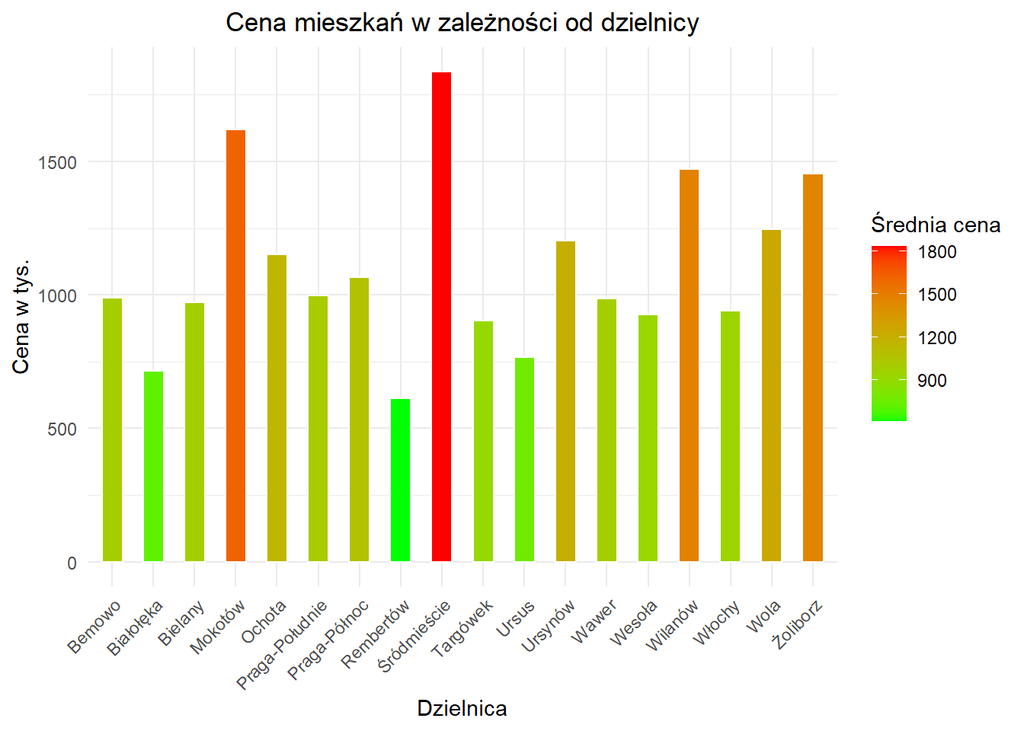

##### **Wnioski**

Na podstawie przedstawionych danych dotyczących średnich cen mieszkań w poszczególnych dzielnicach Warszawy możemy wyróżnić kilka wniosków:

1. **Zróżnicowanie Atrakcyjności Lokalizacyjnej:**
   - Dzielnice centralne, takie jak Śródmieście, prezentują najwyższe ceny mieszkań, co wynika z dogodnego położenia i dostępu do szerokiej gamy usług.
   - Mokotów, Wola, i Wilanów również odznaczają się wyższymi cenami, co jest efektem atrakcyjnej lokalizacji i wysokiego standardu życia.
2. **Warunki dla Inwestorów i Poszukujących Oszczędności:**
   - Dzielnice z niższymi średnimi cenami, takie jak Rembertów czy Białołęka, mogą być atrakcyjne dla inwestorów szukających potencjalnych wzrostów wartości nieruchomości.
   - Osoby poszukujące bardziej przystępnych cen mogą znaleźć okazje do zakupu mieszkań w obszarach, gdzie ceny są relatywnie niższe.
3. **Zróżnicowanie Oferowanych Standardów Życia:**
   - Wyższe ceny w dzielnicach centralnych mogą być odzwierciedleniem dostępu do ekskluzywnych usług, kulturalnych atrakcji i biznesowych centrów.
   - Dla tych, dla których koszty są kluczowym czynnikiem, dzielnice z niższymi cenami oferują równie atrakcyjne możliwości zakupu, choć zazwyczaj w mniej zurbanizowanych obszarach.
4. **Wpływ Infrastruktury na Ceny:**
   - Dostępność do rozwiniętej infrastruktury, takiej jak komunikacja publiczna, sklepy, i tereny rekreacyjne, może wpływać na wyższe ceny nieruchomości.

Podsumowując, analiza danych cen mieszkań w Warszawie pozwala na bardziej kompleksową ocenę rynku nieruchomości, z uwzględnieniem różnorodnych aspektów, takich jak lokalizacja, standard życia, oraz potencjał inwestycyjny.

#### **Wykres zależności ceny mieszkań od powierzchni w metrach kwadratowych**

Wykresy zależności ceny mieszkań od powierzchni dostarczają istotnych informacji dotyczących wpływu rozmiaru nieruchomości na jej cenę. Dane przedstawione są na dwóch wykresach, prezentujących średnie ceny mieszkań dla dwóch przedziałów powierzchniowych: do 200 m² oraz powyżej 200 m². W obu wykresach na na osi X znajdują się przedziały powierzchni, podzielone na kategorie, natomiast na osi Y umieszczona jest średnia cena mieszkania dla danego przedziału powierzchni. Wykorzystano punkty na końcach słupków, by ułatwić odczytanie średnich cen mieszkań dla konkretnych przedziałów powierzchni.

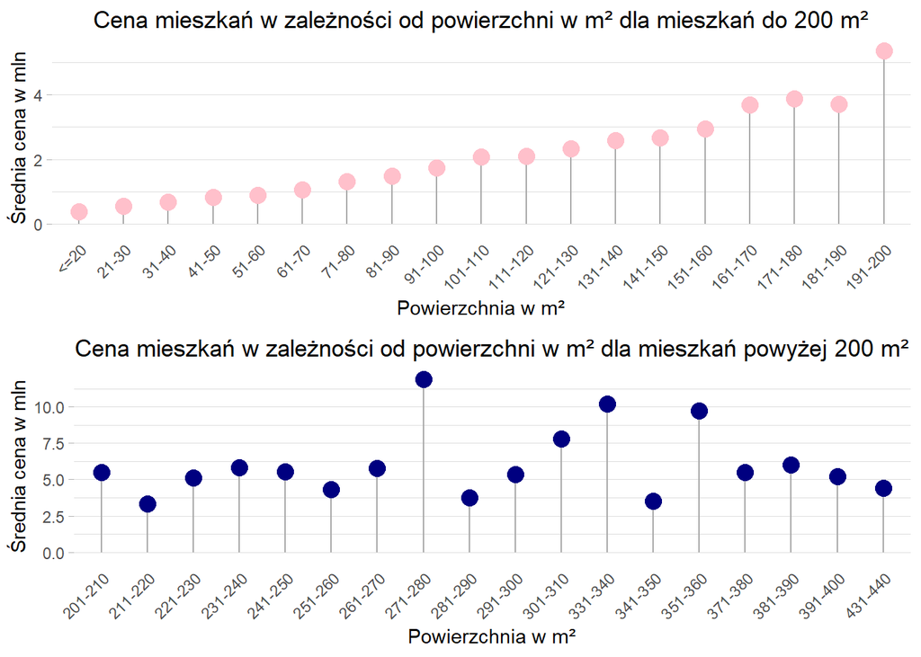

##### **Wnioski**

**Dla Mieszkań powyżej 200 m²**

- Wartości cen dla tych mieszkań są znacznie wyższe niż dla mniejszych mieszkań, co jest zgodne z oczekiwaniami.
- Cena za metr kwadratowy waha się, ale w ogólności utrzymuje się na wyższym poziomie niż dla mieszkań o mniejszej powierzchni.

##### **Interpetacje**

Analiza ta pozwala na lepsze zrozumienie, jak powierzchnia mieszkania wpływa na jego cenę oraz jakie trendy można zaobserwować na rynku nieruchomości w zależności od tego parametru.

#### **Liczba ofert w zależności od roku budowy**

Histogram przedstawiający liczbę ofert mieszkań w zależności od roku budowy nieruchomości stanowi ciekawą wizualizację dynamiki rynku nieruchomości w Warszawie. Na osi OX znajdują się lata budowy, a na osi OY liczba ofert mieszkań w danym roku.

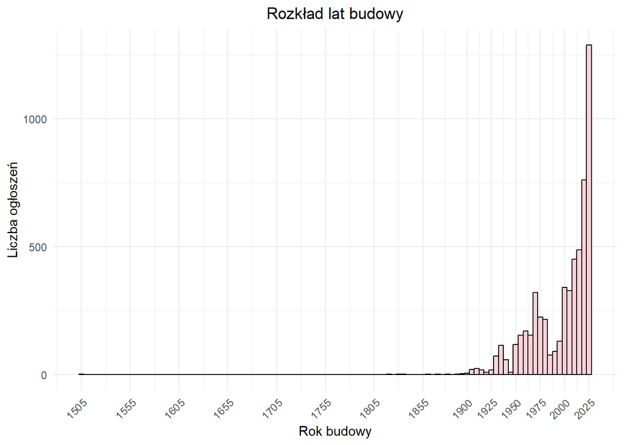

#### **Cena z podziałem na rodzaj zabudowy w zależności od roku budowy**

Animowany wykres przedstawia trend cen mieszkań w Warszawie w zależności od rodzaju zabudowy oraz roku ich budowy. Oś X reprezentuje lata budowy, natomiast oś Y przedstawia cenę mieszkania w milionach złotych. Każda linia na wykresie reprezentuje inny rodzaj zabudowy, a punkty na linii są rozmieszczone wzdłuż osi X zgodnie z rokiem budowy mieszkania.

[figure not shown]

##### **Wnioski**

1. **Wzrost cen z czasem:** Ogólnie można zauważyć tendencję wzrostową cen mieszkań w Warszawie w ostatnich latach, bez względu na rodzaj zabudowy.
2. **Różnice między rodzajami zabudowy:** Wykres uwydatnia różnice w cenach między różnymi rodzajami zabudowy. Apartamentowce mogą charakteryzować się wyższymi cenami niż bloki czy kamienice.
3. **Wpływ roku budowy:** Starsze nieruchomości mogą wykazywać niższe ceny, ale istnieją wyjątki, zwłaszcza w przypadku nowoczesnych apartamentowców.
4. **Ciągła zmienność cen:** Linie na wykresie pozwalają zauważyć niestabilność cen w zależności od roku budowy, co może wynikać z różnych czynników rynkowych.

##### **Interpretacje**

1. **Rok budowy istotny dla ceny:** Wybór nieruchomości zależny jest od preferencji i budżetu kupującego. Starsze budynki mogą być bardziej atrakcyjne cenowo, ale nowoczesne oferty zazwyczaj charakteryzują się wyższymi cenami.
2. **Różnice między rodzajami zabudowy:** Wybór między apartamentowcami, blokami a kamienicami może wpływać na cenę nieruchomości. Lokalizacja, standard i dodatkowe udogodnienia mogą również wpływać na wartość mieszkania.
3. **Trendy rynkowe:** Dynamika zmian cen mieszkań odzwierciedla trendy rynkowe i popyt na konkretne rodzaje zabudowy w różnych okresach czasu.

Animowany charakter wykresu pozwala śledzić zmiany cen w czasie, co może być szczególnie przydatne do analizy długoterminowych trendów na rynku nieruchomości.

#### **Cena za metr w zależności od osiedla - najdroższe osiedla w dzielnicach**

Wykres przedstawia średnie ceny za metr kwadratowy mieszkań w najdroższych osiedlach poszczególnych dzielnic Warszawy. Na osi X znajdują się nazwy osiedli, natomiast na osi Y cena za metr kwadratowy w polskich złotych. Wykres pozwala porównać, które osiedla są najbardziej ekskluzywne i charakteryzują się wyższymi cenami za metr kwadratowy.

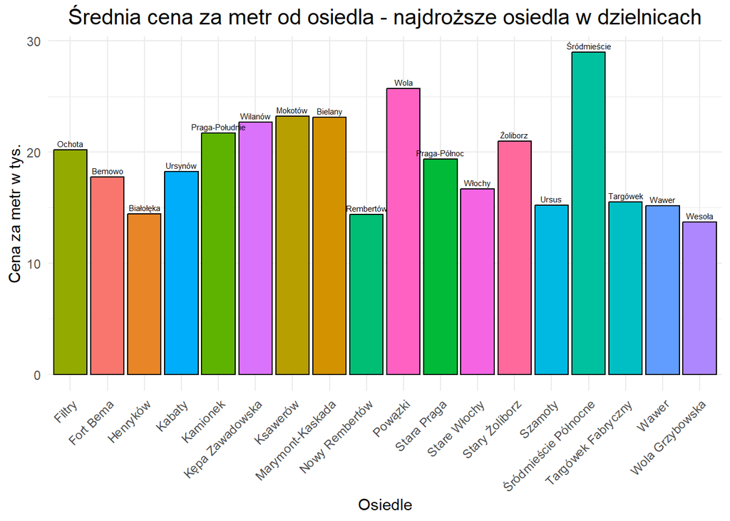

##### **Wnioski**

1. **Zróżnicowane ceny wśród najdroższych osiedli:** Wykres uwydatnia znaczne zróżnicowanie cen za metr kwadratowy nawet wśród najbardziej prestiżowych osiedli różnych dzielnic. Wskazuje to na istotność lokalizacji osiedla dla kształtowania cen nieruchomości.
2. **Najwyższe ceny w centralnych lokalizacjach:** Dzielnicą, w której występują najwyższe ceny za metr, jest Śródmieście Północne. Również osiedla takie jak “Powązki” w dzielnicy Wola czy “Ksawerów” w dzielnicy Mokotów prezentują wysokie średnie ceny za metr kwadratowy. To potwierdza tendencję do wyższych cen w centralnych i prestiżowych częściach miasta.

##### **Interpretacje**

1. **Lokalizacja jako kluczowy czynnik cenowy:** Analiza wykresu wskazuje, że lokalizacja osiedla jest kluczowym czynnikiem wpływającym na cenę za metr kwadratowy. Dostęp do atrakcji, infrastruktury czy prestiżu danej dzielnicy istotnie wpływa na wartość nieruchomości.
2. **Wybór osiedla a preferencje nabywców:** Dla potencjalnych nabywców jest to istotna informacja, umożliwiająca lepsze dopasowanie ofert do własnych preferencji. Osoby poszukujące mieszkań w konkretnych dzielnicach mogą dodatkowo uwzględniać zróżnicowanie cenowe między osiedlami.

Wykres stanowi użyteczne narzędzie do zrozumienia zróżnicowania cenowego w obrębie poszczególnych dzielnic Warszawy. Analiza może wspierać proces podejmowania decyzji zakupowej, umożliwiając bardziej precyzyjny wybór nieruchomości z uwzględnieniem lokalizacyjnych preferencji i dostępnych budżetów.

#### **Zależność średniej ceny za metr kwadratowy od osiedla na interaktywnej mapie Warszawy**

Interaktywna mapa Warszawy przedstawiająca zależność średniej ceny za metr kwadratowy od osiedla. Na mapie umieszczone są interaktywne kropki, gdzie każda kropka reprezentuje jedno osiedle. Im większa kropka, tym wyższa średnia cena za metr kwadratowy na danym osiedlu. Przez najechanie myszką na kropkę można uzyskać informacje dotyczące dzielnicy, osiedla oraz średniej ceny za metr kwadratowy.

[interactive chart not shown]

#### **Średnia wysokość czynszu w zależności od dzielnicy z podziałem na położenie względem Wisły**

##### **Warszawa lewobrzeżna**

Wykres gęstości przedstawia rozkład średnich czynszów w poszczególnych osiedlach Warszawy lewobrzeżnej, z podziałem na dzielnice. Oś X ukazuje średni czynsz, natomiast oś Y prezentuje gęstość rozkładu, odzwierciedlając różne wartości średnich czynszów w poszczególnych obszarach.

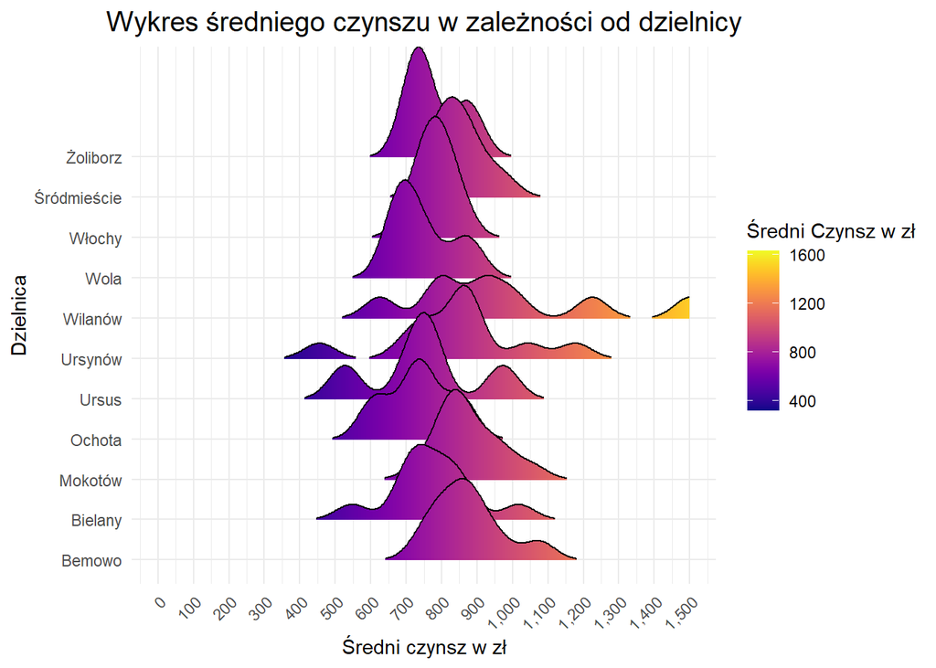

##### **Wnioski**

1. **Różnorodność cen w obrębie dzielnic:** W dzielnicach takich jak Wilanów czy Ursynów-Centrum, obserwujemy zróżnicowane średnie czynsze, co może wynikać z lokalnych uwarunkowań, takich jak prestiż osiedli czy dostęp do dodatkowych udogodnień.
2. **Ceny a centralna lokalizacja:** Obszary Śródmieścia prezentują zróżnicowanie cen, odzwierciedlając różnice między ekskluzywnymi obszarami a bardziej dostępnymi pod względem cenowym.
3. **Zróżnicowanie cen w dzielnicach o niższych standardach:** Dzielnie takie jak Bemowo czy Bielany również prezentują zróżnicowanie cen, co może być rezultatem lokalizacji konkretnych osiedli w obrębie tych dzielnic. Osiedla blisko centrów handlowych czy z dogodnym dostępem do komunikacji publicznej mogą cechować się wyższymi czynszami.

##### **Interpretacje**

1. **Ekskluzywne osiedla z wyższymi czynszami:** Warto zauważyć, że osiedla w dzielnicach takich jak Wilanów czy Ursynów-Centrum prezentują wyższe średnie czynsze, co może wynikać z ekskluzywności tych obszarów oraz dostępu do dodatkowych udogodnień.
2. **Zróżnicowanie centralnych obszarów:** Śródmieście prezentuje zróżnicowane średnie czynsze, co może wynikać z faktu, że obejmuje zarówno obszary prestiżowe, jak i te mniej ekskluzywne, co wpływa na zróżnicowanie cen w całej dzielnicy.
3. **Lokalne czynniki wpływające na ceny:** Dzielnice takie jak Bemowo czy Bielany prezentują zróżnicowanie cen, co może być rezultatem lokalnych uwarunkowań, takich jak dostępność do centrów handlowych czy sieci komunikacji miejskiej, wpływających na poziom czynszów.

##### **Warszawa prawobrzeżna**

Wykres gęstości przedstawia rozkład średnich czynszów w poszczególnych osiedlach Warszawy prawobrzeżnej, z podziałem na dzielnice. Oś X ukazuje średni czynsz, a oś Y prezentuje gęstość rozkładu, odzwierciedlając różne wartości średnich czynszów w poszczególnych obszarach.

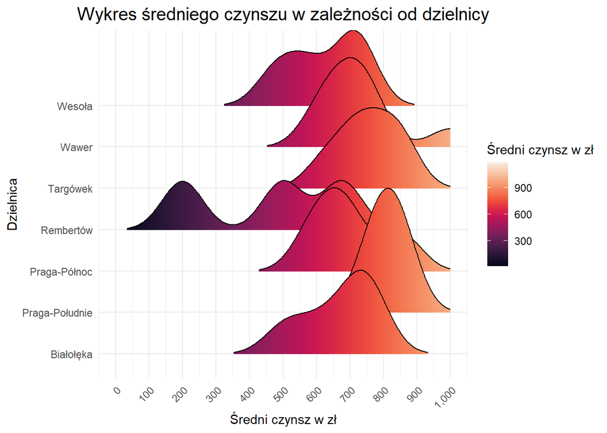

##### **Wnioski**

1. **Zróżnicowane ceny w Białołęce:** Dzielnica Białołęka prezentuje zróżnicowane średnie czynsze na poszczególnych osiedlach, co może wynikać z lokalnych uwarunkowań, takich jak lokalizacja czy standard osiedli.
2. **Wysokie czynsze w Gocławiu i Starej Pradze:** Osiedla w dzielnicach Praga-Południe i Praga-Północ prezentują wyższe średnie czynsze, co może być związane z centralną lokalizacją i dostępem do atrakcji miejskich.
3. **Zróżnicowanie w Wawrze:** Dzielnica Wawer prezentuje zróżnicowane ceny na poszczególnych osiedlach, co może wynikać z różnic w lokalizacji oraz dostępności do infrastruktury.

##### **Interpretacje**

1. **Lokalne uwarunkowania w Białołęce:** Białołęka charakteryzuje się zróżnicowanymi cenami czynszów na poszczególnych osiedlach, co może być efektem różnic w standardzie i lokalizacji.
2. **Centralna lokalizacja a koszty mieszkań:** Osiedla w Pradze-Południe, Pradze-Północ i Gocławiu prezentują wyższe średnie czynsze, co może wynikać z centralnej lokalizacji i dostępu do usług oraz infrastruktury.
3. **Zróżnicowanie cen w Wawrze:** Dzielnica Wawer wykazuje zróżnicowanie cen czynszów, co może być rezultatem różnic w lokalizacji konkretnych osiedli w obrębie tej dzielnicy. Osiedla blisko atrakcji czy z dostępem do komunikacji publicznej mogą cechować się wyższymi czynszami.

#### **Wykres korelacji zmiennych numerycznych**

Wykres korelacji prezentuje zależności między różnymi zmiennymi numerycznymi w analizowanych danych dotyczących nieruchomości. Kolor czerwony oznacza silną dodatnią korelację, bliżej 1, natomiast kolor niebieski reprezentuje silną ujemną korelację, bliżej -1. Im bardziej wartość korelacji zbliża się do 0, tym intensywność koloru jest słabsza.

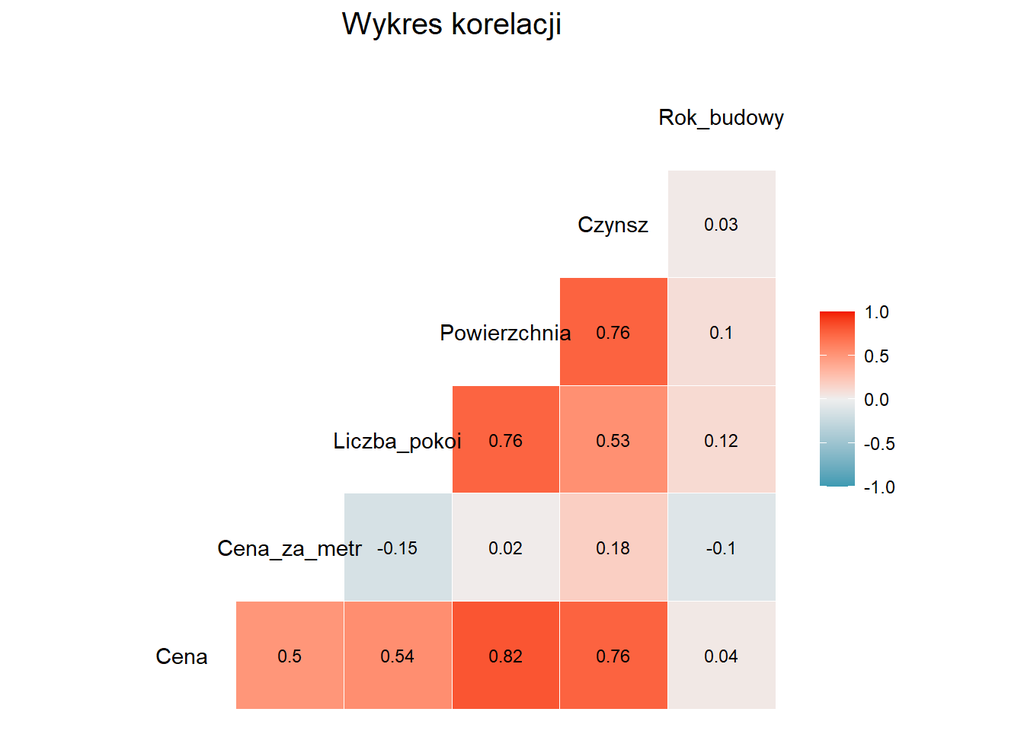

##### **Interpretacje**

Podsumowując, analiza korelacji pomaga zrozumieć wzajemne relacje między zmiennymi numerycznymi, co może być istotne przy podejmowaniu decyzji związanych z nieruchomościami.

#### **Posiadanie wind: Warszawa lewo- i prawobrzeżna**

Wykres przedstawia podział posiadania windy w dzielnicach lewobrzeżnej i prawobrzeżnej Warszawy. Dwa oddzielne zestawienia obejmują informacje o posiadaniu windy w budynkach, z podziałem na “tak” i “nie”.

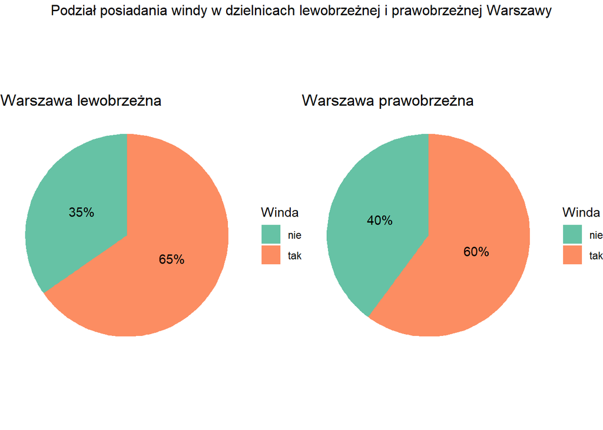

##### **Interpretacje**

1. **Różnice między częściami miasta:** Obserwuje się pewne różnice w dostępie do wind w zależności od lokalizacji. Lewobrzeżna Warszawa wydaje się mieć nieco wyższy odsetek budynków z windą w porównaniu do prawobrzeżnej.
2. **Windy są powszechne:** W obu częściach miasta windy są dość powszechne, a większość budynków jest wyposażona w to udogodnienie.
3. **Potencjalne różnice w strukturze mieszkalnej:** Różnice w dostępie do windy mogą wynikać z różnic w strukturze mieszkalnej, lokalnych uwarunkowań czy inwestycjach deweloperskich w poszczególnych obszarach.

#### Rodzaj ogrzewania w zależności od typu zabudowy i dzielnicy

Wykres przedstawia zależność rodzaju ogrzewania od typu zabudowy w różnych dzielnicach Warszawy. Każdy punkt na wykresie reprezentuje konkretne połączenie dzielnicy, rodzaju ogrzewania i typu zabudowy.

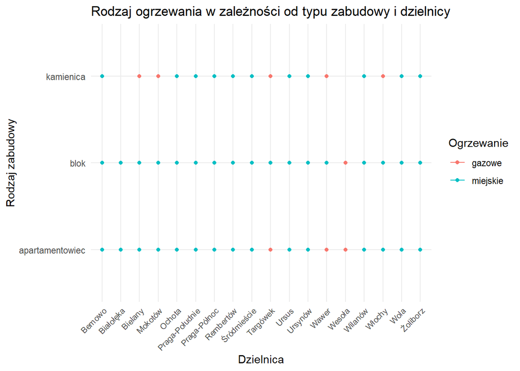

#### **Rozkład ceny za metr kwadratowy w zależności od liczby pokoi**

Na przedstawionym wykresie pudełkowym zaprezentowano rozkład cen za metr kwadratowy mieszkań w Warszawie w zależności od liczby pokoi. Dla każdej kategorii liczby pokoi (od 1 do 10) przedstawiono rozkład cen za metr, co pozwala zobaczyć, jak zmienia się cena w zależności od liczby pokoi.

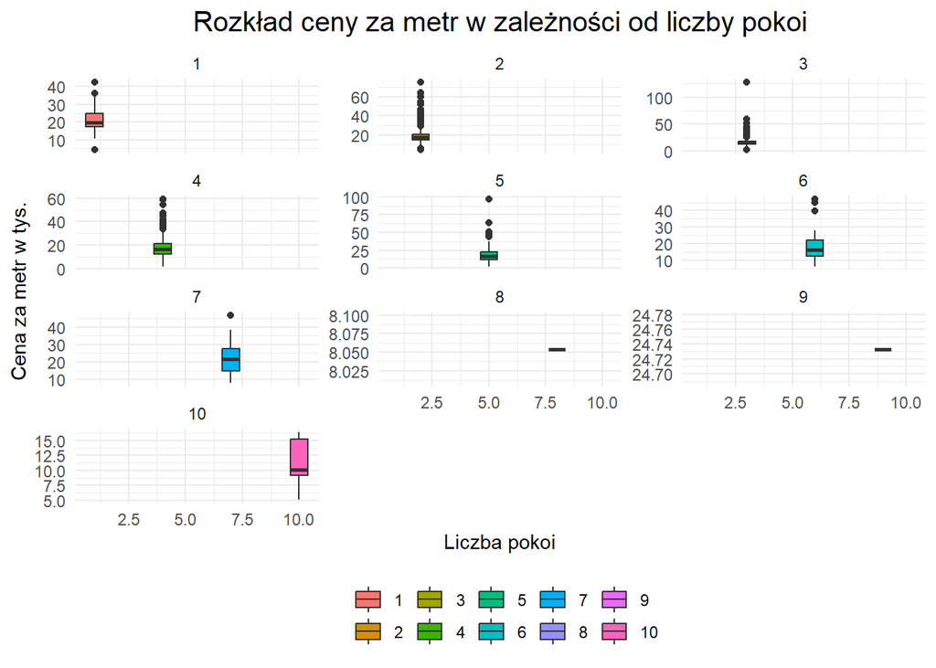

##### **Interpretacje**

1. **Lokalizacja jako kluczowy czynnik:** Wyraźne zróżnicowanie cen w obrębie każdej kategorii liczby pokoi podkreśla, że lokalizacja odgrywa kluczową rolę w kształtowaniu cen nieruchomości. Nawet mieszkania o tej samej liczbie pokoi mogą różnić się ceną w zależności od dzielnicy czy konkretnej lokalizacji.
2. **Elastyczność cenowa:** Obecność wartości odstających wskazuje na elastyczność cenową rynku nieruchomości. Istnieją mieszkania, które znacznie odbiegają ceną od przeciętnej w danej kategorii liczby pokoi, co może wynikać z różnych czynników, takich jak standard wykończenia czy unikalne cechy mieszkania.
3. **Ważność analizy rynku w kontekście preferencji:** Dla potencjalnych nabywców istotne jest zrozumienie, że cena za metr kwadratowy nie jest jedynym wyznacznikiem wartości mieszkania. Analiza rynku w kontekście preferencji dotyczących liczby pokoi oraz lokalizacji może pomóc w dokładniejszym dostosowaniu oferty do oczekiwań kupującego.

Wykres dostarcza cennych informacji dla osób poszukujących nieruchomości, pomagając zrozumieć, jak różne czynniki wpływają na cenę mieszkań. Decyzja zakupowa powinna być oparta nie tylko na liczbie pokoi, ale również na analizie lokalizacji i innych istotnych kryteriów.

#### **Rozkład liczby ofert w zależności od piętra**

Wykres przedstawia dostępność mieszkań na poszczególnych piętrach, z uwzględnieniem liczby ofert. Dla każdego piętra przedstawiona jest liczba dostępnych mieszkań.

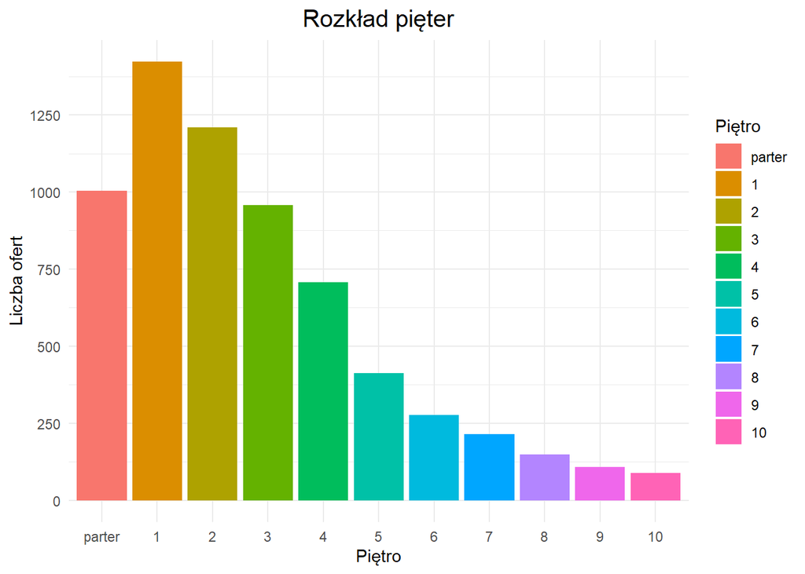

#### **Rozkład posiadania balkonów, ogródków i tarasów w dzielnicach Warszawy**

Wykres przedstawia rozkład posiadania balkonów, ogródków i tarasów w różnych dzielnicach. Dla każdej dzielnicy podano, czy mieszkania posiadają balkon, ogródek, taras, bądź różne kombinacje tych elementów.

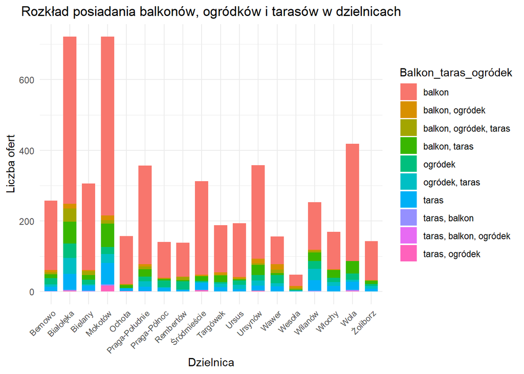

##### **Wnioski**

1. **Zróżnicowanie dostępności przestrzeni zewnętrznej:**
   - Istnieje zróżnicowanie w posiadaniu balkonów, ogródków i tarasów między różnymi dzielnicami.
   - Niektóre dzielnice charakteryzują się większą różnorodnością dostępności przestrzeni zewnętrznej.
2. **Popularność balkonów:**
   - Balkony są powszechnie spotykane w różnych dzielnicach, co sugeruje, że są one standardowym elementem mieszkań.
3. **Rzadkość tarasów i ogródków:**
   - Tarasy i ogródki są mniej powszechne niż balkony, co może wynikać z ograniczonej przestrzeni dostępnej dla tego rodzaju elementów.

##### **Interpretacje**

1. **Preferencje mieszkańców:**
   - Mieszkania z balkonami są powszechne, co może wynikać z potrzeby dostępu do przestrzeni na świeżym powietrzu.
   - Ogródki i tarasy są mniej powszechne, ale w niektórych dzielnicach ich popularność może wzrastać.
2. **Różnorodność ofert:**
   - Dzielnicę Wilanów cechuje posiadanie tarasów i balkonów, co może wynikać z atrakcyjnej lokalizacji i zielonych terenów w okolicy.
   - Dzielnica Ursus ma tendencję do posiadania balkonów, ale ogródki są rzadziej spotykane.
3. **Wpływ lokalizacji na dostępność przestrzeni zewnętrznej:**
   - Lokalizacja w centrum, tak jak dzielnica Śródmieście, może wpływać na mniejszą dostępność przestrzeni zewnętrznej, co jest widoczne w mniejszej ilości tarasów i ogródków.
   - Dzielnice zielone, takie jak Wesoła, mogą charakteryzować się większą ilością ofert z ogródkami.

#### **Rozkład rynku nieruchomości z podziałem na typ zabudowy**

Wykres przedstawia rozkład rynku nieruchomości z podziałem na trzy różne typy zabudowy: apartamentowce, bloki i kamienice. Dla każdego typu zabudowy uwzględniono rynek pierwotny i wtórny. Kolor fioletowy oznacza rynek wtórny, a niebieski rynek pierwotny.

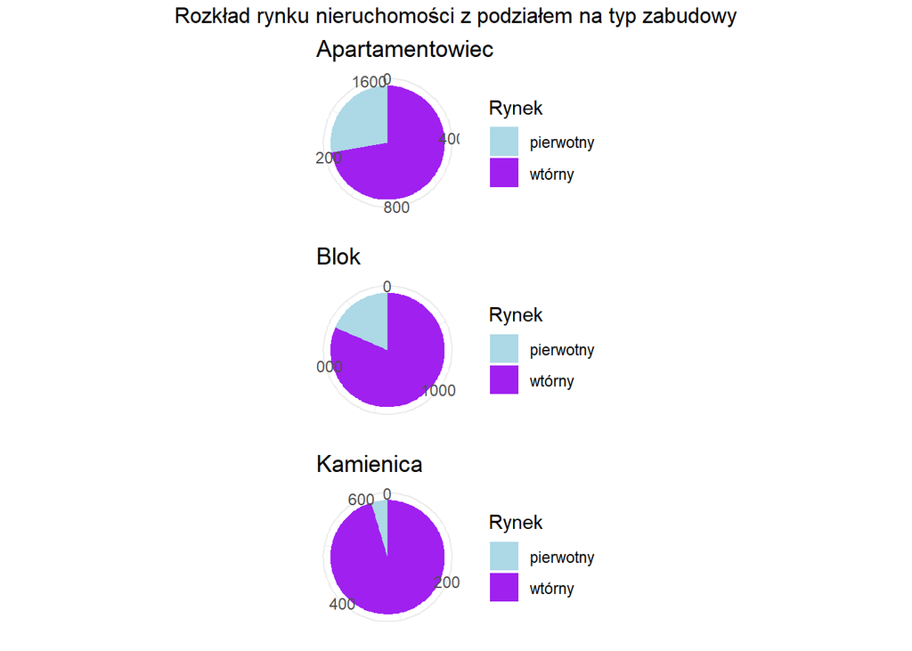

##### **Interpretacje**

1. Apartamentowce:

- W analizowanym zbiorze danych znajduje się łącznie 1,678 apartamentowców.
- Rynek wtórny jest bardziej aktywny niż pierwotny dla apartamentowców.
- Widać pewną zmienność, ale ogólnie rynek wtórny dominuje w liczbie transakcji.

2. Bloki:

- Bloki stanowią największą grupę nieruchomości, z 2,814 obiektami.
- Rynek wtórny jest znacznie bardziej zdominowany niż rynek pierwotny dla tego typu zabudowy.
- Można zauważyć, że bloki są bardziej popularne na rynku wtórnym.

##### **Wnioski**

Analizując dane rynku nieruchomości z podziałem na typ zabudowy, można zauważyć, że każdy rodzaj posiada swoje unikalne cechy. Apartamentowce są liczne, a rynek wtórny jest bardziej aktywny. Bloki stanowią największą grupę, a rynek wtórny dominuje. Kamienice są najrzadsze, ale rynek wtórny może mieć większą zróżnicowaną ofertę. Ważne jest monitorowanie tych trendów dla lepszego zrozumienia dynamiki rynku nieruchomości.

#### **Zależność ceny za metr kwadratowy od typu ogłoszeniodawcy i dzielnicy**

Wykres przedstawia zależność ceny za metr kwadratowy nieruchomości od typu ogłoszeniodawcy i dzielnicy. Dane zawierają informacje o typie ogłoszeniodawcy (prywatny, biuro nieruchomości, deweloper) oraz dzielnicy, w której znajduje się nieruchomość. Cena za metr kwadratowy została również uwzględniona w analizie. Na osi X znajduje się typ ogłoszeniodawcy, natomiast na osi Y cena za metr kwadratowy. Dodatkowo, różne kolory na wykresie reprezentują różne dzielnice.

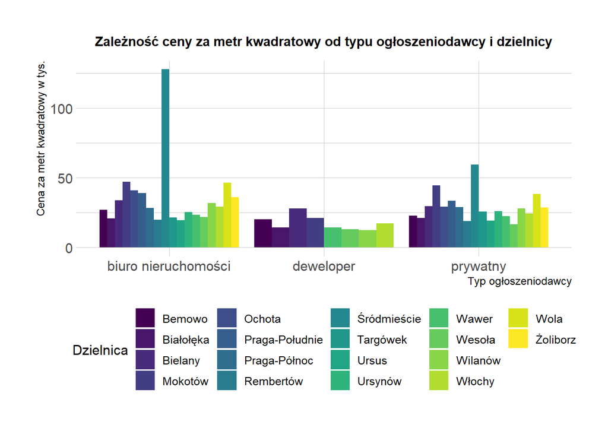

##### **Interpretacje**

1. **Wysokie ceny w centrum:**
   - Nieruchomości znajdujące się w centrum miasta (Śródmieście) często są droższe, co może wynikać z atrakcyjnej lokalizacji i dostępu do różnych udogodnień.
2. **Różnice między dzielnicami:**
   - Istnieje znaczne zróżnicowanie cen w zależności od dzielnicy, co może wynikać z różnic w standardzie życia, dostępności do terenów zielonych czy infrastruktury.

Analiza wykresu może pomóc w zidentyfikowaniu trendów na rynku nieruchomości, co może być przydatne zarówno dla kupujących, jak i sprzedających.